# Assignment4-checkpoint

*You are currently looking at **version 1.1** of this notebook. To download notebooks and datafiles, as well as get help on Jupyter notebooks in the Coursera platform, visit the [Jupyter Notebook FAQ](https://www.coursera.org/learn/python-machine-learning/resources/bANLa) course resource.*

## Assignment 4 - Understanding and Predicting Property Maintenance Fines

This assignment is based on a data challenge from the Michigan Data Science Team ([MDST](http://midas.umich.edu/mdst/)).

The Michigan Data Science Team ([MDST](http://midas.umich.edu/mdst/)) and the Michigan Student Symposium for Interdisciplinary Statistical Sciences ([MSSISS](https://sites.lsa.umich.edu/mssiss/)) have partnered with the City of Detroit to help solve one of the most pressing problems facing Detroit - blight. [Blight violations](http://www.detroitmi.gov/How-Do-I/Report/Blight-Complaint-FAQs) are issued by the city to individuals who allow their properties to remain in a deteriorated condition. Every year, the city of Detroit issues millions of dollars in fines to residents and every year, many of these fines remain unpaid. Enforcing unpaid blight fines is a costly and tedious process, so the city wants to know: how can we increase blight ticket compliance?

The first step in answering this question is understanding when and why a resident might fail to comply with a blight ticket. This is where predictive modeling comes in. For this assignment, your task is to predict whether a given blight ticket will be paid on time.

All data for this assignment has been provided to us through the [Detroit Open Data Portal](https://data.detroitmi.gov/). **Only the data already included in your Coursera directory can be used for training the model for this assignment.** Nonetheless, we encourage you to look into data from other Detroit datasets to help inform feature creation and model selection. We recommend taking a look at the following related datasets:

- [Building Permits](https://data.detroitmi.gov/Property-Parcels/Building-Permits/xw2a-a7tf)
- [Trades Permits](https://data.detroitmi.gov/Property-Parcels/Trades-Permits/635b-dsgv)
- [Improve Detroit: Submitted Issues](https://data.detroitmi.gov/Government/Improve-Detroit-Submitted-Issues/fwz3-w3yn)
- [DPD: Citizen Complaints](https://data.detroitmi.gov/Public-Safety/DPD-Citizen-Complaints-2016/kahe-efs3)
- [Parcel Map](https://data.detroitmi.gov/Property-Parcels/Parcel-Map/fxkw-udwf)

We provide you with two data files for use in training and validating your models: train.csv and test.csv. Each row in these two files corresponds to a single blight ticket, and includes information about when, why, and to whom each ticket was issued. The target variable is compliance, which is True if the ticket was paid early, on time, or within one month of the hearing data, False if the ticket was paid after the hearing date or not at all, and Null if the violator was found not responsible. Compliance, as well as a handful of other variables that will not be available at test-time, are only included in train.csv.

Note: All tickets where the violators were found not responsible are not considered during evaluation. They are included in the training set as an additional source of data for visualization, and to enable unsupervised and semi-supervised approaches. However, they are not included in the test set.

**File descriptions** (Use only this data for training your model!)

```
readonly/train.csv - the training set (all tickets issued 2004-2011)
readonly/test.csv - the test set (all tickets issued 2012-2016)
readonly/addresses.csv & readonly/latlons.csv - mapping from ticket id to addresses, and from addresses to lat/lon coordinates.
 Note: misspelled addresses may be incorrectly geolocated.
```

**Data fields**

train.csv & test.csv

```
ticket_id - unique identifier for tickets
agency_name - Agency that issued the ticket
inspector_name - Name of inspector that issued the ticket
violator_name - Name of the person/organization that the ticket was issued to
violation_street_number, violation_street_name, violation_zip_code - Address where the violation occurred
mailing_address_str_number, mailing_address_str_name, city, state, zip_code, non_us_str_code, country - Mailing address of the violator
ticket_issued_date - Date and time the ticket was issued
hearing_date - Date and time the violator's hearing was scheduled
violation_code, violation_description - Type of violation
disposition - Judgment and judgement type
fine_amount - Violation fine amount, excluding fees
admin_fee - $20 fee assigned to responsible judgments
```

state_fee - $10 fee assigned to responsible judgments late_fee - 10% fee assigned to responsible judgments discount_amount - discount applied, if any clean_up_cost - DPW clean-up or graffiti removal cost judgment_amount - Sum of all fines and fees grafitti_status - Flag for graffiti violations

train.csv only

```
payment_amount - Amount paid, if any
payment_date - Date payment was made, if it was received
payment_status - Current payment status as of Feb 1 2017
balance_due - Fines and fees still owed
collection_status - Flag for payments in collections
compliance [target variable for prediction]
 Null = Not responsible
 0 = Responsible, non-compliant
 1 = Responsible, compliant
compliance_detail - More information on why each ticket was marked compliant or non-compliant
```

## Evaluation

Your predictions will be given as the probability that the corresponding blight ticket will be paid on time.

The evaluation metric for this assignment is the Area Under the ROC Curve (AUC).

Your grade will be based on the AUC score computed for your classifier. A model which with an AUROC of 0.7 passes this assignment, over 0.75 will recieve full points.

For this assignment, create a function that trains a model to predict blight ticket compliance in Detroit using `readonly/train.csv`. Using this model, return a series of length 61001 with the data being the probability that each corresponding ticket from `readonly/test.csv` will be paid, and the index being the ticket_id.

Example:

```
ticket_id
   284932    0.531842
   285362    0.401958
   285361    0.105928
   285338    0.018572
             ...
   376499    0.208567
   376500    0.818759
   369851    0.018528
   Name: compliance, dtype: float32
```

### Hints

- Make sure your code is working before submitting it to the autograder.
- Print out your result to see whether there is anything weird (e.g., all probabilities are the same).
- Generally the total runtime should be less than 10 mins. You should NOT use Neural Network related classifiers (e.g., MLPClassifier) in this question.
- Try to avoid global variables. If you have other functions besides blight_model, you should move those functions inside the scope of blight_model.
- Refer to the pinned threads in Week 4's discussion forum when there is something you could not figure it out.

```python
import pandas as pd
import numpy as np
import matplotlib.pyplot as plt
from sklearn import preprocessing
import seaborn as sns
from sklearn.model_selection import cross_val_score, train_test_split

from sklearn.model_selection import StratifiedKFold
from sklearn.neighbors import KNeighborsClassifier
from sklearn.linear_model import LogisticRegression
from sklearn.tree import DecisionTreeClassifier
from sklearn.model_selection import GridSearchCV
from sklearn.metrics import accuracy_score

from sklearn.ensemble import RandomForestClassifier
from sklearn.ensemble import GradientBoostingClassifier
from sklearn.ensemble import AdaBoostClassifier

import warnings
warnings.filterwarnings('ignore')
```

```
raw training data columns:
Index(['agency_name', 'inspector_name', 'violator_name',
       'violation_street_number', 'violation_street_name',
       'violation_zip_code', 'mailing_address_str_number',
       'mailing_address_str_name', 'city', 'state', 'zip_code',
       'non_us_str_code', 'country', 'ticket_issued_date', 'hearing_date',
       'violation_code', 'violation_description', 'disposition', 'fine_amount',
       'admin_fee', 'state_fee', 'late_fee', 'discount_amount',
       'clean_up_cost', 'judgment_amount', 'payment_amount', 'balance_due',
       'payment_date', 'payment_status', 'collection_status',
       'grafitti_status', 'compliance_detail', 'compliance', 'address', 'lat',
       'lon'],
      dtype='object')
selected data features:
Index(['city', 'zip_code', 'violation_code', 'disposition', 'fine_amount',
       'judgment_amount', 'grafitti_status', 'lat', 'lon'],
      dtype='object')
```

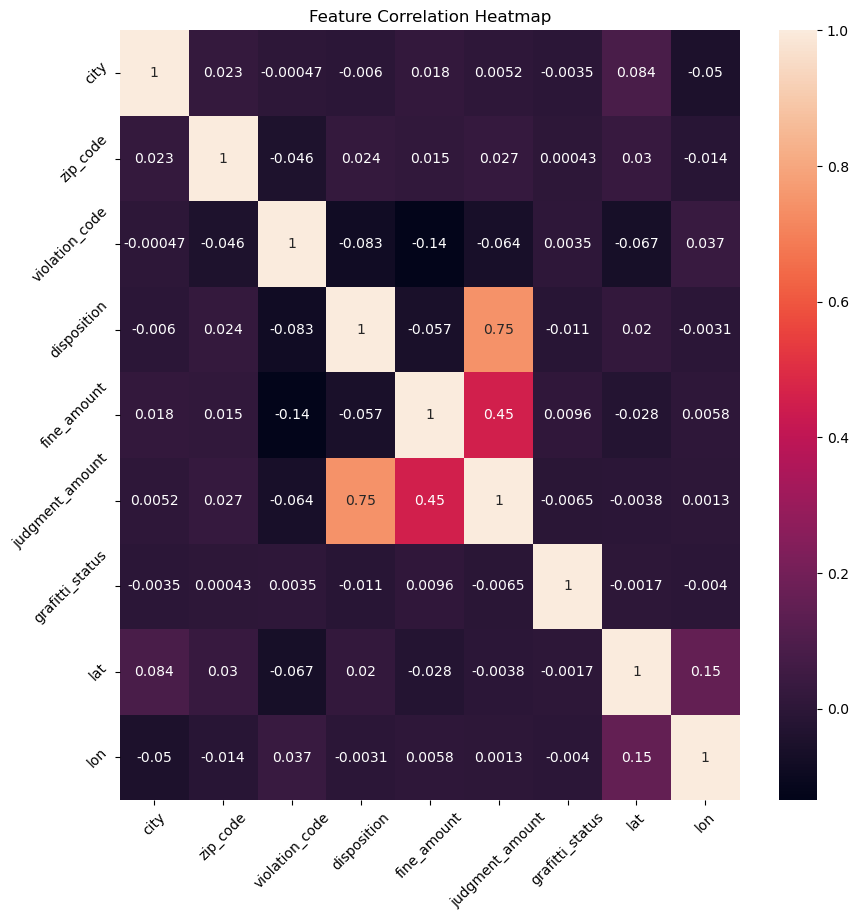

```
                     city  zip_code  violation_code  disposition  fine_amount  \
city             1.000000  0.022542       -0.000469    -0.005950     0.018419
zip_code         0.022542  1.000000       -0.045541     0.024436     0.015280
violation_code  -0.000469 -0.045541        1.000000    -0.083015    -0.135039
disposition     -0.005950  0.024436       -0.083015     1.000000    -0.057201
fine_amount      0.018419  0.015280       -0.135039    -0.057201     1.000000
judgment_amount  0.005209  0.026897       -0.064058     0.747115     0.452465
grafitti_status -0.003504  0.000435        0.003539    -0.011196     0.009561
lat              0.083947  0.029616       -0.066934     0.019619    -0.027988
lon             -0.050329 -0.014140        0.036850    -0.003145     0.005784

                 judgment_amount  grafitti_status       lat       lon
city                    0.005209        -0.003504  0.083947 -0.050329
zip_code                0.026897         0.000435  0.029616 -0.014140
violation_code         -0.064058         0.003539 -0.066934  0.036850
disposition             0.747115        -0.011196  0.019619 -0.003145
fine_amount             0.452465         0.009561 -0.027988  0.005784
judgment_amount         1.000000        -0.006461 -0.003759  0.001276
grafitti_status        -0.006461         1.000000 -0.001737 -0.003967
lat                    -0.003759        -0.001737  1.000000  0.154939
lon                     0.001276        -0.003967  0.154939  1.000000

model selection
K Neighbors
Mean Score: 0.920465

Logistic Regression
Mean Score: 0.924119

Decision Tree
Mean Score: 0.886608

perform grid search on best performing model (linear regression)
grid search values:
{'penalty': ['l1', 'l2'], 'C': [0.001, 0.01, 0.1, 1, 10, 100, 1000]}
grid search tuned model parameters:
{'C': 0.01, 'class_weight': None, 'dual': False, 'fit_intercept': True, 'intercept_scaling': 1, 'l1_ratio': None, 'max_iter': 100, 'multi_class': 'ovr', 'n_jobs': None, 'penalty': 'l1', 'random_state': None, 'solver': 'liblinear', 'tol': 0.0001, 'verbose': 0, 'warm_start': False}

model accuracy score:
0.9225913674353197
```

[output cut: 21 more lines]

```

Gradient Boosting
Mean Score: 0.740228

ADA Booster
Mean Score: 0.731505

perform grid search on best performing model (ada booster)
grid search tuned model parameters:
{'algorithm': 'SAMME.R', 'base_estimator': None, 'learning_rate': 1.5, 'n_estimators': 50, 'random_state': None}

model accuracy score:
0.9254997842657846

Ticket ID and probability value:
```

```
ticket_id
284932    0.491861
285362    0.487822
285361    0.492692
285338    0.492734
285346    0.493527
            ...
376496    0.485844
376497    0.485844
376499    0.492655
376500    0.492655
369851    0.488940
Length: 61001, dtype: float64
```

```python
def blight_model():

    # read training data file and combine with location data into a full set of training data
    # with ticket_id as the index
    train_raw = pd.read_csv('train.csv',encoding='latin1',low_memory=False)
    latlons = pd.read_csv('latlons.csv', encoding='latin1')
    addresses = pd.read_csv('addresses.csv', encoding='latin1')

    # latlons maps address to coordinates and addresses maps ticket_id to address
    loc = addresses.merge(latlons, how='inner', on='address')
    train_full = train_raw.merge(loc, how='inner', on='ticket_id').set_index('ticket_id')

    print('raw training data columns:')
    print(train_full.columns)

    # remove columns that leak data or hold info for target var
    # these features only in training data
    train_set = train_full.drop(['payment_amount','balance_due','payment_date','payment_status',
                                 'collection_status','compliance_detail'],axis=1)

    # feature selection
    # encode string type features to include them in correlation heatmap

    # drop features that don't make sense to encode
    # drop more after inspection of correlation heatmap
    # to be dropped from final test data as well
    drop_features = ['inspector_name','violator_name','violation_street_number','violation_street_name',
                           'violation_zip_code','mailing_address_str_number','mailing_address_str_name',
                            'non_us_str_code','hearing_date','violation_description','admin_fee','state_fee',
                            'late_fee','discount_amount','clean_up_cost','address',
                           'agency_name','state','country','ticket_issued_date']

    train = train_set.drop(drop_features,axis=1).fillna(method='pad')

    train['grafitti_status'].fillna('',inplace=True)

    # separate target variable from feature data
    X = train.drop(['compliance'],axis=1)
    y = train['compliance']

    le = preprocessing.LabelEncoder()

    print('\nselected data features:')
    print(X.columns)

    for feature in X.columns:
        if isinstance(feature, str):

            #print(feature)
            le.fit(X[feature])
            X[feature] = le.transform(X[feature])

    # create correlation heatmap
    plt.figure(figsize=(10,10))
    correlation = X.corr()
    sns.heatmap(correlation, annot=True)
    plt.title('Feature Correlation Heatmap')
    plt.xticks(rotation=45)
    plt.yticks(rotation=45)

    plt.show()

    #print(train_set.columns)
    print(correlation)

    # scale and split training data
    # use train test split on training data, save test data for final validation
    scaler = preprocessing.MinMaxScaler()
    X = scaler.fit_transform(X)

    X_train, X_test, y_train, y_test = train_test_split(X,y, random_state=0)

#######################################################################################################################

    # try a few different models and compare accuracy scores

    print('\nmodel selection')
    models = []
    models.append(('K Neighbors', KNeighborsClassifier()))
    models.append(('Logistic Regression', LogisticRegression(solver='liblinear', multi_class='ovr')))
    models.append(('Decision Tree', DecisionTreeClassifier()))

    # use stratified k-fold splits for model selection
    output = []
    names = []
    for name, model in models:
        kfold = StratifiedKFold(n_splits=3, random_state=0, shuffle=True)
        cv_results = cross_val_score(model, X_train, y_train, cv=kfold, scoring='accuracy')
        output.append(cv_results)
        names.append(name)
        print('%s\nMean Score: %f\n' % (name, cv_results.mean()) )

    # use classifier with highest average cross validation score (logistic regression)
    # perform gridsearch to tune parameters
    print('perform grid search on best performing model (linear regression)')
    lr_grid = LogisticRegression(solver='liblinear', multi_class='ovr')
    grid_values = {'penalty': ['l1','l2'], 'C': [0.001,0.01,0.1,1,10,100,1000]}
    print('grid search values:')
    print(grid_values)
    gridsearch = GridSearchCV(lr_grid, grid_values, scoring='roc_auc')

    model = gridsearch.fit(X_train, y_train)
    best_params = model.best_estimator_.get_params()
    print('grid search tuned model parameters:')
    print(best_params)

    # now we have the best performing parameters and we can evaluate using accuracy score
    lr_clf = LogisticRegression(**best_params).fit(X_train,y_train)
    pred = lr_clf.predict(X_test)
    print('\nmodel accuracy score:')
    print(accuracy_score(y_test, pred))

    # have a good accuracy score, now repeat steps to run test data through LR classifier

#######################################################################################################################

    # load test data
    test_raw = pd.read_csv('test.csv',encoding='latin1',low_memory=False)
    loc = addresses.merge(latlons, how='inner', on='address')
    test_full = test_raw.merge(loc, how='inner', on='ticket_id').set_index('ticket_id')
    test = test_full.drop(drop_features,axis=1).fillna(method='pad')
    test['grafitti_status'].fillna('',inplace=True)


    for feature in test.columns:
        if isinstance(feature, str):
            le.fit(test[feature])
            test[feature] = le.transform(test[feature])

    X_test_final = scaler.fit_transform(test)

#######################################################################################################################

    # now create the series of probability values for each ticket
    pred_prob = lr_clf.predict_proba(X_test_final)[:,1]
    pred_prob_s = pd.Series(pred_prob,index=test.index)

    print('\nTicket ID and probability value:')
    print(pred_prob_s)

#######################################################################################################################

    # Logistic Regression classifier performed poorly when evaluated by AUC
    # repeat previous model selection steps with classidier models in sklearn ensemble package

    print('Logistic Regression classifier performed poorly when evaluated by AUC')
    print('repeat previous model selection steps with classidier models in sklearn ensemble package')

    print('\nmodel selection:')
    ensemble_models = []
    ensemble_models.append(('Random Forest', RandomForestClassifier()))
    ensemble_models.append(('Gradient Boosting', GradientBoostingClassifier()))
    ensemble_models.append(('ADA Booster', AdaBoostClassifier()))

    # use stratified k-fold splits for model selection
    output = []
    names = []
    for name, model in ensemble_models:
        kfold = StratifiedKFold(n_splits=3, random_state=0, shuffle=True)
        cv_results = cross_val_score(model, X_train, y_train, cv=kfold, scoring='roc_auc')
        output.append(cv_results)
        names.append(name)
        print('%s\nMean Score: %f\n' % (name, cv_results.mean()) )

    # use classifier with highest average cross validation score (ada booster)
    # perform gridsearch to tune parameters
    print('perform grid search on best performing model (ada booster)')
    ada_grid = AdaBoostClassifier()
    grid_values = {'learning_rate': [.5,.75,1,1.25,1.5,1.75,2]}

    gridsearch = GridSearchCV(ada_grid, grid_values, scoring='roc_auc')

    model = gridsearch.fit(X_train, y_train)
    best_params = model.best_estimator_.get_params()
    print('grid search tuned model parameters:')
    print(best_params)

    # now we have the best performing parameters and we can evaluate using accuracy score
    adaboost_clf = AdaBoostClassifier(**best_params).fit(X_train,y_train)
    pred = adaboost_clf.predict(X_test)
    print('\nmodel accuracy score:')
    print(accuracy_score(y_test, pred))

    # now create the series of probability values for each ticket
    pred_prob = adaboost_clf.predict_proba(X_test_final)[:,1]
    pred_prob_s = pd.Series(pred_prob,index=test.index)

    print('\nTicket ID and probability value:')
    #print(pred_prob_s)

    return pred_prob_s
blight_model()
```

```python
# the following cells are meant to correct an issue with data files in the wrong location
```

```python
# !ls
```

```python
# !cat readonly/test.csv > test.csv
```

```python
# !ls
```

```python
# !cat readonly/latlons.csv > latlons.csv
# !cat readonly/addresses.csv > addresses.csv
```

```python
# !ls
```

### The following cells were used to modularize the blight model and run sections at a time before combining into a single blight_model function